# MATH 2310 Reliability

Jakob Balkovec

2024-05-13

```r
plot_function <- function(data_frame,
                          func_name,
                          plot_title,
                          lines = FALSE,
                          line_color = "brown",
                          point_color = "blue") {

  p <- ggplot(data_frame, aes(x = Time, y = Function)) +
    labs(x = "Time", y = func_name, title = plot_title) +
    geom_line(color = line_color) +
    geom_point(color = point_color) +
    ylim(0, max(data_frame$Function + 0.2)) +
    theme_minimal() +
    theme(plot.title = element_text(hjust = 0.5, face = "bold"))

  if (lines) {
    p <- p + geom_vline(xintercept = 5, color = "lightblue", linetype = "dashed") +
             geom_vline(xintercept = 10, color = "lightblue", linetype = "dashed")  +
             geom_vline(xintercept = 15, color = "lightblue", linetype = "dashed")  +

          annotate("text", x = 5, y = max(data_frame$Function), label = "5 yrs", vjust = -0.5, color = "black") +
          annotate("text", x = 10, y = max(data_frame$Function), label = "10 yrs", vjust = -0.5, color = "black") +
          annotate("text", x = 15, y = max(data_frame$Function), label = "15 yrs", vjust = -0.5, color = "black")
  }
  return(p)
}
```

## Activity One

Assume that a certain product can be modeled with a normal failure law having a mean lifetime of 10 years, with a standard deviation of 2 years. In R, define a vector `t <- seq(0,20)` representing the years over which we will examine failure probability.

```r
# Commonly used variables

t <- seq(0,20)

mean_lifetime <- 10
sd_lifetime <- 2
```

##### **[Question A]**

- *Generate the probability density function `f(t)` based on the mean and standard deviation lifetimes.*

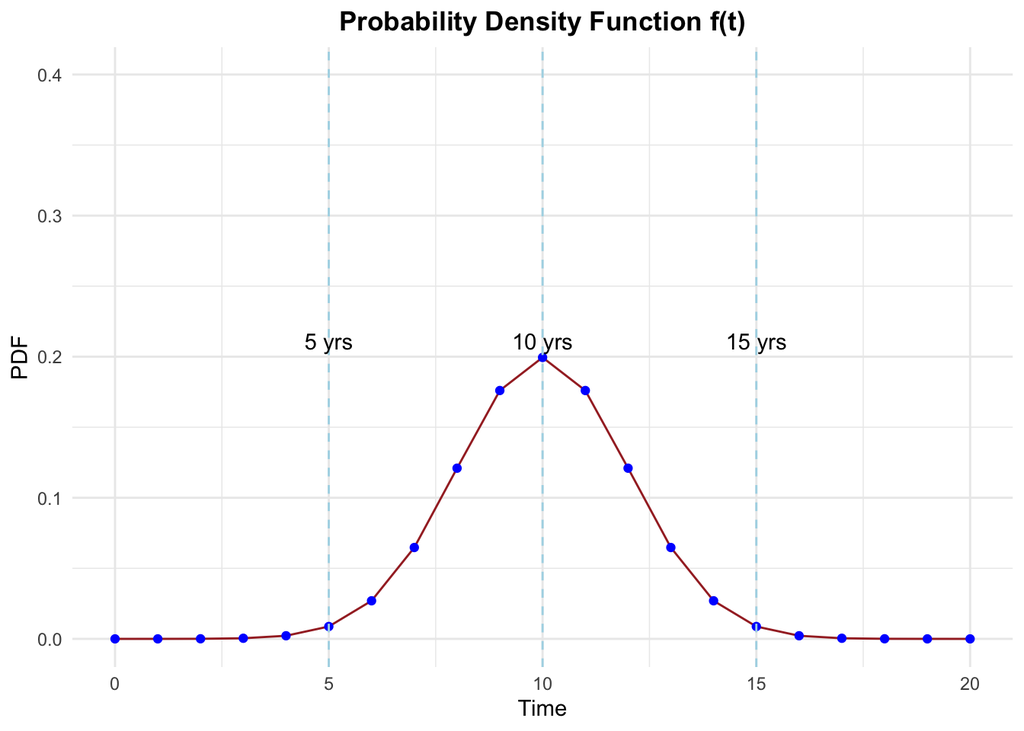

```r
# Normal failure law
#
# Mean lifetime: 10yrs
# SD: 2yrs

# Our probability density function [f(t)]
pdf <- dnorm(t, mean = mean_lifetime, sd = sd_lifetime)

# Combine in a DF for better readability. Using "kable" to prettify the output
pdf_df <- data.frame(Time = t, Function = pdf)
plot_function(data_frame = pdf_df, func_name = "PDF", plot_title = "Probability Density Function f(t)", lines=TRUE)
```

##### **[Question B]**

- *Calculate the cumulative distribution function `F(t)`*

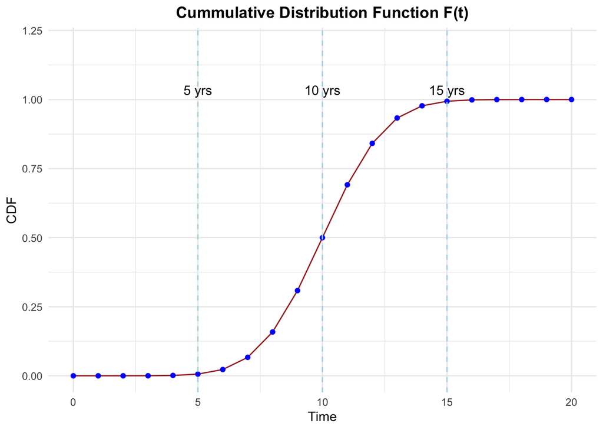

```r
# Normal failure law
#
# Mean lifetime: 10yrs
# SD: 2yrs

# Our cumulative distribution function [F(t)]
cdf <- pnorm(t, mean = mean_lifetime, sd = sd_lifetime)

cdf_df <- data.frame(Time = t, Function = cdf)
plot_function(data_frame = cdf_df, func_name = "CDF", plot_title = "Cummulative Distribution Function F(t)", lines = TRUE )
```

##### **[Question C]**

- *Calculate the reliability function `R(t)`, and plot it as a function of time.*

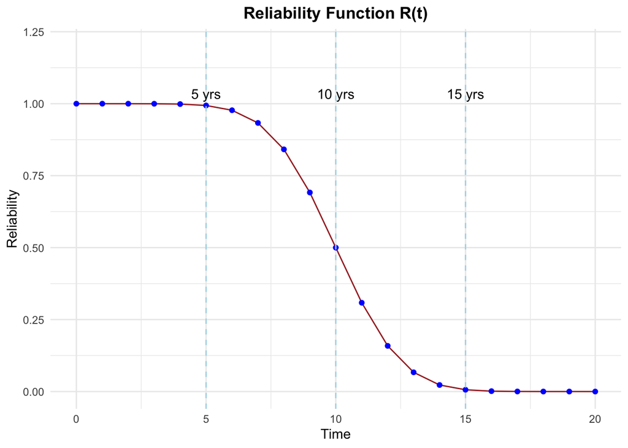

```r
# Normal failure law
#
# Mean lifetime: 10yrs
# SD: 2yrs

# Our reliability function [R(t)]
reliability <- pnorm(t, mean = mean_lifetime, sd = sd_lifetime, lower.tail = FALSE)

# Pack the data into a data-frame
plot_data <- data.frame(Time = t, Function = reliability)
plot_function(data_frame = plot_data, func_name = "Reliability", plot_title = "Reliability Function R(t)", lines = TRUE)
```

##### **[Question D]**

- *Calculate the hazard function `z(t)`, and plot it as a function of time.*

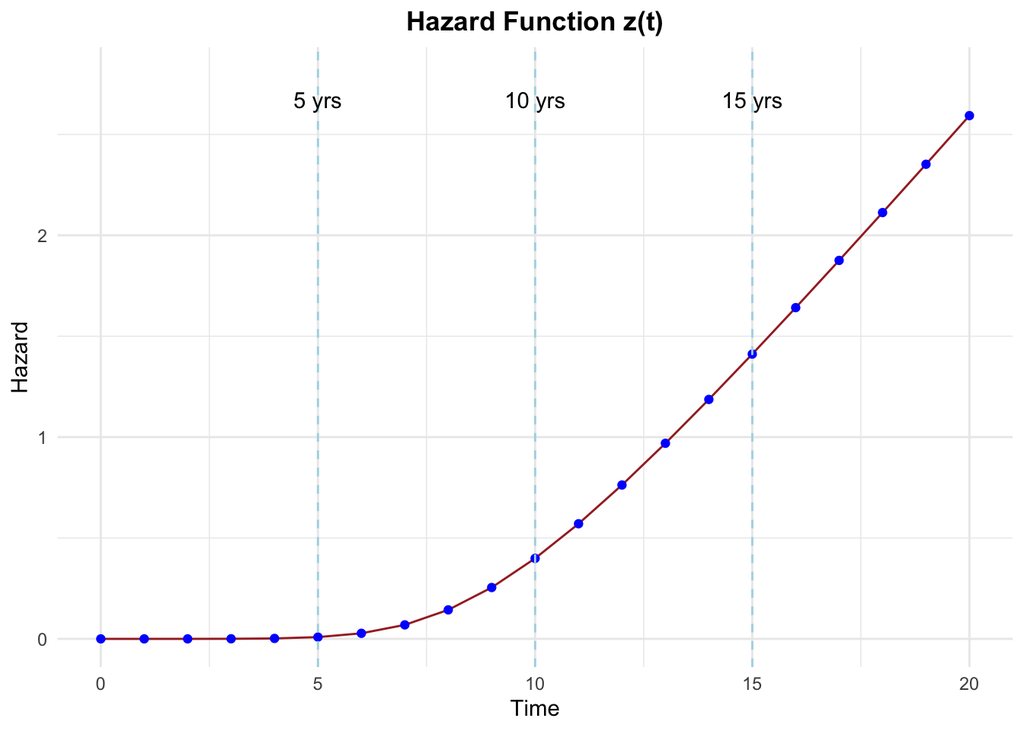

```r
# Normal failure law
#
# Mean lifetime: 10yrs
# SD: 2yrs

# Our hazard function [z(t)]
hazard <- dnorm(t, mean = mean_lifetime, sd = sd_lifetime) / (1 - pnorm(t, mean = mean_lifetime, sd = sd_lifetime))

plot_data <- data.frame(Time = t, Function = hazard)
plot_function(data_frame = plot_data, func_name = "Hazard", plot_title = "Hazard Function z(t)", lines = TRUE)
```

##### **[Question E]**

- *Based on your result, what type of failure rate do products with normal failure laws have (increasing, decreasing, or constant over time)?*
- Products subject to normal failure laws exhibit a growing likelihood of failure throughout time. When we focus on the first vertical line at 5 years, we notice a very slow but steady increase in the hazard function. Moving into the next segment from 5 years to 10 years, the upward trend becomes more visible, signaling a sharper rise in the function. This trend persists across the remaining sections, highlighting a continuous growth in the probability of failure over time.

## Activity Two

In most real-world applications, we will not know the population distribution for product lifetime. Instead, we will have to estimate it. Suppose that we suspect that the lifetime of a particular product should follow an exponential distribution. We collect data on the lifetimes, in years, for a sample of products in the data set **`lifetimes.txt`**

```r
plot_histogram <- function(data, binwidth = 1, plot_title) {
  hist_plot <-  ggplot(data, aes(x = Lifetime)) +
                geom_histogram(binwidth = binwidth, fill = "skyblue", color = "black") +
                geom_density(aes(y = ..count..), fill = "orange", alpha = 0.5) +
                labs(title = plot_title,
                     x = "Lifetime",
                     y = "Frequency") +
                theme_minimal() +
                theme(plot.title = element_text(hjust = 0.5, face = "bold"))

  return(hist_plot)
}

plot_qq <- function(data) {
  lambda <- 1 / mean(data$Lifetime)
  exp_quantiles <- qexp(ppoints(length(data$Lifetime)), rate = lambda)

  data_sorted <- sort(data$Lifetime)
  empirical_quantiles <- quantile(data_sorted, probs = ppoints(length(data$Lifetime)))

  qq_data <- data.frame(
    Empirical = empirical_quantiles,
    Exponential = exp_quantiles
  )

  qq_plot <- ggplot(qq_data, aes(x = Exponential, y = Empirical)) +
            geom_point(color = "blue1", size = 1.5, shape = 2) +
            geom_abline(slope = 1, intercept = 0, color = "brown4", linetype = "dashed") +
            labs(x = "Exponential Distribution Quantiles", y = "Empirical Quantiles",
                 title = "Q-Q Plot: Lifetime Data vs. Exponential Distribution") +
            theme_minimal() +
            theme(plot.title = element_text(hjust = 0.5, face = "bold"))
  return(qq_plot)
}
```

##### **[Question A]**

- *Let’s examine the distribution of lifetimes. In R,construct a histogram of the lifetimes. Does it look reasonable to assume an exponential distribution for this data?*

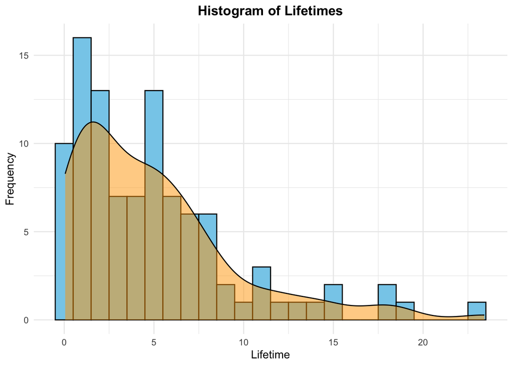

```r
lifetimes_df <- read.delim("lifetime.txt") # Done
hist <- plot_histogram(lifetimes_df, plot_title = "Histogram of Lifetimes")
qq_plot <- plot_qq(lifetimes_df)

hist
```

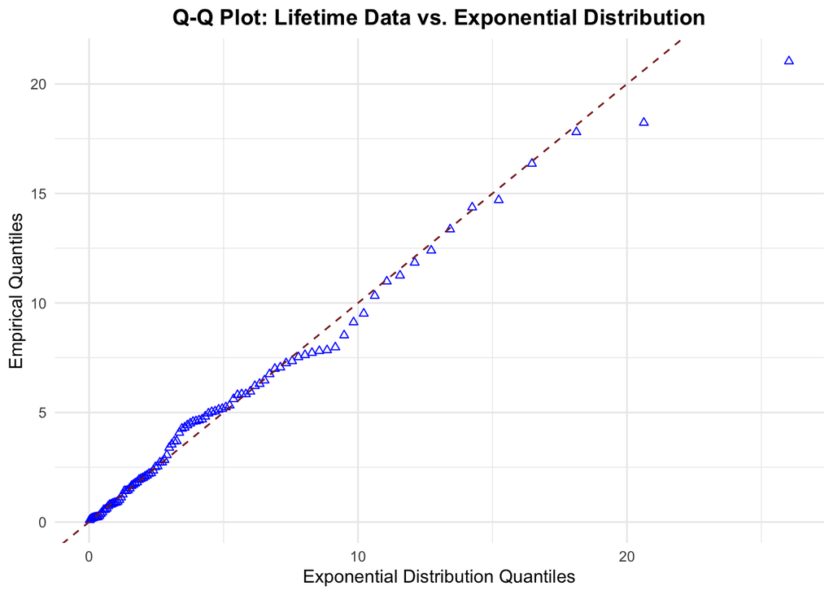

```r
qq_plot
```

##### **[Question B]**

- *To use an exponential distribution, we need to know `λ`. Using the relationship between `λ` and the mean of an exponential, estimate `λ` for this population based on the sample mean of the data.*

```r
sample_mean <- mean(lifetimes_df$Lifetime)

lambda_est <- 1/sample_mean

cat("[Estimated λ]: ", round(lambda_est, digits = 4))
```

```
## [Estimated λ]:  0.2036
```

##### **[Question C]**

- *Now let’s examine the reliability and failure rate for these items. Once again create a vector of time values `t`, this time ranging from 0 to 25, and calculate the reliability function and the failure rate (i.e., the hazard function) based on the exponential distribution, using the estimated value of `λ` based on your data.*

```r
time <- seq(0, 25)

# Our reliability function [R(t)]
reliability <- pexp(time, rate = lambda_est, lower.tail = FALSE)

# Our hazard function [z(t)]
hazard <- dexp(time, rate = lambda_est) / (1 - pexp(time, rate = lambda_est))
```

##### **[Question D]**

- *Graph the estimated reliability function for this product overtime.*

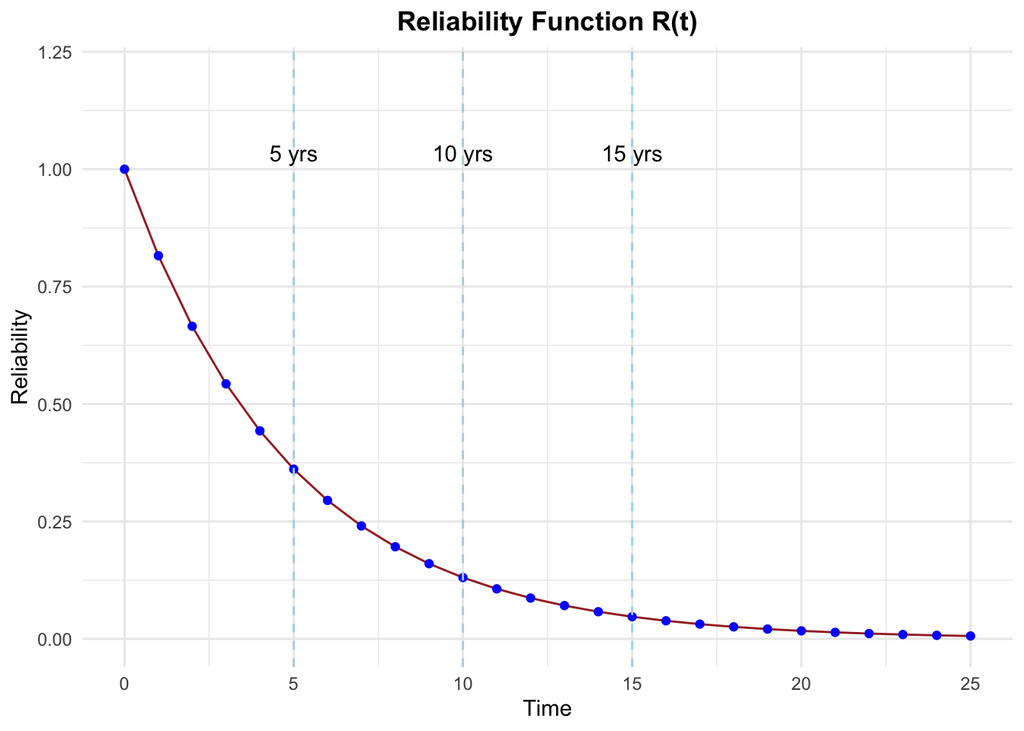

```r
plot_data <- data.frame(Time = time, Function = reliability)
plot_function(data_frame = plot_data, func_name = "Reliability", plot_title = "Reliability Function R(t)", lines = TRUE)
```

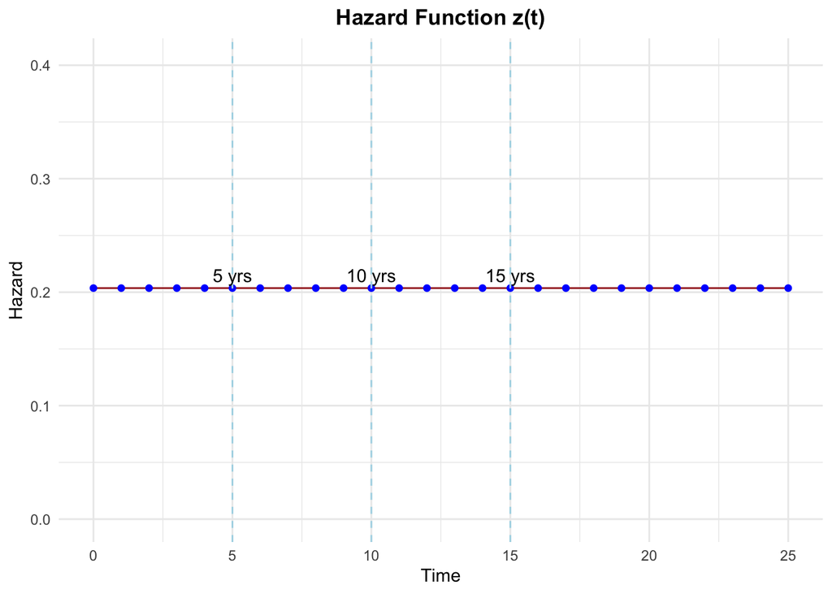

```r
plot_data <- data.frame(Time = time, Function = hazard)
plot_function(data_frame = plot_data, func_name = "Hazard", plot_title = "Hazard Function z(t)", lines = TRUE)
```

##### **[Question E]**

- *Graph the estimated hazard function for this product overtime. Based on your result, what type of failure rate do products with exponential failure laws have (increasing, decreasing, or constant)?*
- Products subject to exponential failure laws exhibit a constant rate of failure throughout time. When we focus on the first vertical line at 5 years, we can’t notice a decrease nor can we notice an increase in the hazard function. This trend persists across the remaining sections, highlighting a constant probability of failure over time.

##### **[Question F]**

- *For the exponential distribution, rather than using R’s built in functionality, we could also use the formulas we’ve learned previously for `f(t)` and `F(t)` for an exponential distribution to find exact formulas for `R(t)` and `z(t)`. Find `R(t)` and `z(t)` this way. Do your results match the graphs you made?*

```r
# Summary:

# R(t) : e ^(-λt) or exp(-λ*t)
# z(t) : λ
```

###### Calculations

**Probability Density Function (PDF):**
$$f(t) = \lambda e^{-\lambda t}$$

**Cumulative Distribution Function (CDF):**
$$\begin{align*}
\int_{t}^{0} \lambda e^{-\lambda t} dt &= \int_{0}^{t} \lambda
e^{-\lambda t} dt \\
&= \lambda \int_{0}^{t} e^{-\lambda t} dt \\
&= \lambda \left[- \frac{e^{-\lambda t}}{\lambda} \right]_{0}^{t} \\
&= \left[-e^{-\lambda t} \right]_{0}^{t} \\
&= - e^{-\lambda t} + 1 \\
&= 1 - e^{-\lambda t}
\end{align*}$$

**Reliability Function (Survival Function):**
$$\begin{align*}
R(t) &= 1 - F(t) \\
&= 1 - (1 - e^{-\lambda t}) \\
&= e^{-\lambda t}
\end{align*}$$

**Hazard Function:**
$$\begin{align*}
z(t) &= \frac{f(t)}{R(t)} \\
&= \frac{\lambda e^{-\lambda t}}{e^{-\lambda t}} \\
&= \lambda
\end{align*}$$

The obtained results align with those from earlier sections of the problem. The function $R(t) = e^{-\lambda t}$ corresponds to the decreasing exponential curve depicted in part D. Similarly, $z(t) = \lambda$ corresponds to the other graph in part D, representing a constant failure rate. In essence, $z(t) = \lambda$ holds true for all $t$ within the domain.

**Jakob Balkovec**